# 2026年7月6日 比赛日志1：项目分析

各位好久不见！今天给大家带来点不一样的东西，实际上，我刚刚报名参加了Kaggle的代码竞赛：Biohub - Cell Tracking During Development。我想在这里开始分享自己项目的进度，今天先分析一下这个竞赛给出的要求和训练集和测试集数据。

## Biohub - Cell Tracking During Development（ https://www.kaggle.com/competitions/biohub-cell-tracking-during-development ）

这个竞赛所要解决的问题是 → 在延时三维成像显微镜图像中追踪细胞。注意本次比赛使用的成像对象是斑马鱼的胚胎，是活体，所以它有着全部的生物的生理学过程，这对解决这一问题有着明确的影响  
这个问题的难点在于以下几点：

1. 显微镜图像的对比度，明暗等像素层面的变化绝不仅仅来源于细胞本身的生理学变化，而是更多地来自于仪器自身的调节，因此**仪器噪声**必须被考虑。另外，显微镜本身的成像特点也会影响结果，比如Z轴的分辨率明显不如X轴和Y轴，这是物理性质决定的，没有什么很好的解决办法。
2. 显微镜下的细胞实际上特征并不足够显著，同时也经常发生变化，这也是大量自动化工具难以获得良好效果的原因。实际上即使对于人类，也需要经过一段时间的训练，再加上耗费大量时间的反复比对才能找到相对应的细胞。
3. 最特别的是，活体细胞不仅仅会随着时间的推进而移动，其本身就会**变形**和**分裂**。实际上，本次竞赛使用的是活体斑马鱼胚胎细胞。胚胎细胞为了生长有着夸张的活动效率。也就是说，我们面对的是最会移动，变形和分裂的一类细胞。

本次的训练集给出的数据格式如下：  
视频：`Zarr`格式  
标注信息：`geff`格式  
给大家看看如何读取一个切片↓

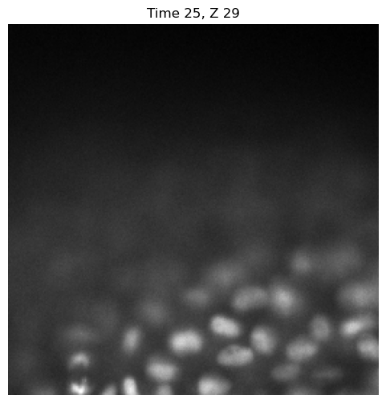

```python
import zarr
import matplotlib.pyplot as plt

zarr_path = r"C:\PhD Project\Kaggle\biohub-cell-tracking-during-development\train\6bba_0c7fa718.zarr"

root = zarr.open(zarr_path, mode="r")
arr = root["0"]
t = 25
z = 29

slice_2d = arr[t, z]

plt.figure(figsize=(6,6))
plt.imshow(slice_2d, cmap="gray")
plt.title(f"Time {t}, Z {z}")
plt.axis("off")
plt.show()
```

你会发现图片中有一些模糊不清的成团亮点，那些就是被荧光染色的细胞核。当然这样的一张图没有什么意义，在现实的科研工作中，我们不得不结合动画一点一点手动分析，这会消耗研究人员大量时间，不得不说的确是个瓶颈。

再给大家看看如何加上geff注释进行可视化：

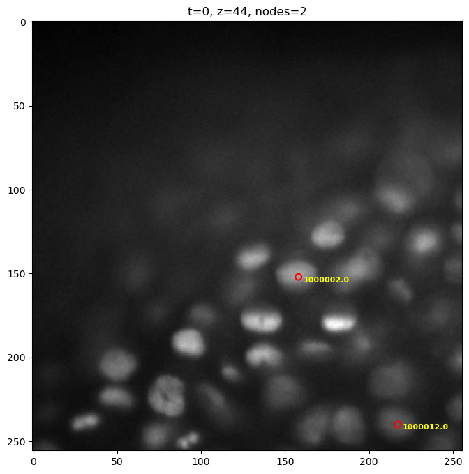

```python
import zarr
import pandas as pd
import numpy as np
import matplotlib.pyplot as plt

zarr_path = r"C:\PhD Project\Kaggle\biohub-cell-tracking-during-development\train\6bba_0c7fa718.zarr"
geff_path = r"C:\PhD Project\Kaggle\biohub-cell-tracking-during-development\train\6bba_0c7fa718.geff"

zarr_root = zarr.open(zarr_path, mode="r")
img = zarr_root["0"][:]

geff_root = zarr.open(geff_path, mode="r")

node_ids = geff_root["nodes/ids"][:]
t_vals = geff_root["nodes/props/t/values"][:]
z_vals = geff_root["nodes/props/z/values"][:]
y_vals = geff_root["nodes/props/y/values"][:]
x_vals = geff_root["nodes/props/x/values"][:]

nodes_df = pd.DataFrame({
    "node_id": node_ids,
    "t": t_vals,
    "z": z_vals,
    "y": y_vals,
    "x": x_vals,
})

t_show = 0
z_show = 44

nodes_slice = nodes_df[(nodes_df["t"] == t_show) & (nodes_df["z"] == z_show)]


plt.figure(figsize=(8, 8))

plt.imshow(img[t_show, z_show], cmap="gray")

# geff point + node_id
for _, row in nodes_slice.iterrows():
    x, y = row["x"], row["y"]
    node_id = row["node_id"]

    # red point
    plt.scatter([x], [y], s=40, edgecolors="red", facecolors="none", linewidths=1.5)

    # node_id
    plt.text(x + 3, y + 3, str(node_id),
             color="yellow", fontsize=8, weight="bold")

plt.title(f"t={t_show}, z={z_show}, nodes={len(nodes_slice)}")
plt.show()
```

很容易发现，大多数应该是细胞的地方没有标注。这是对的，比赛界面中强调了，只有部分细胞被注释了，整体来说是稀疏的，因此我们不得不考虑到这一点。今天对这个项目的分析就到这里了，明天咱们来读官方给的baseline代码，各位，明天见！

[🐾返回主页](https://nyarlathotep438.github.io)

[🐈‍⬛GitHub Profile](https://github.com/nyarlathotep438)